# Lab 6.1

## `distinct()`

`distinct()` looks for all unique observations in rows. This is a little tricky because it can look like it is working column-wise, but it is actually working row-wise.

One helpful approach to new data is to find any duplicated rows. If we first look at the dimensions of the penguins data, we see it has 344 rows and 8 columns.

```r
summary(penguins)
```

```
##       species          island    bill_length_mm  bill_depth_mm
##  Adelie   :152   Biscoe   :168   Min.   :32.10   Min.   :13.10
##  Chinstrap: 68   Dream    :124   1st Qu.:39.23   1st Qu.:15.60
##  Gentoo   :124   Torgersen: 52   Median :44.45   Median :17.30
##                                  Mean   :43.92   Mean   :17.15
##                                  3rd Qu.:48.50   3rd Qu.:18.70
##                                  Max.   :59.60   Max.   :21.50
##                                  NA's   :2       NA's   :2
##  flipper_length_mm  body_mass_g       sex           year
##  Min.   :172.0     Min.   :2700   female:165   Min.   :2007
##  1st Qu.:190.0     1st Qu.:3550   male  :168   1st Qu.:2007
##  Median :197.0     Median :4050   NA's  : 11   Median :2008
##  Mean   :200.9     Mean   :4202                Mean   :2008
##  3rd Qu.:213.0     3rd Qu.:4750                3rd Qu.:2009
##  Max.   :231.0     Max.   :6300                Max.   :2009
##  NA's   :2         NA's   :2
```

Using `distinct()` across all rows, we see there are no duplicates. This means every row contains unique observations across all variables.

```r
penguins %>%
  distinct()
```

```
## # A tibble: 344 × 8
##    species island    bill_length_mm bill_depth_mm flipper_length_mm body_mass_g
##    <fct>   <fct>              <dbl>         <dbl>             <int>       <int>
##  1 Adelie  Torgersen           39.1          18.7               181        3750
##  2 Adelie  Torgersen           39.5          17.4               186        3800
##  3 Adelie  Torgersen           40.3          18                 195        3250
##  4 Adelie  Torgersen           NA            NA                  NA          NA
##  5 Adelie  Torgersen           36.7          19.3               193        3450
##  6 Adelie  Torgersen           39.3          20.6               190        3650
##  7 Adelie  Torgersen           38.9          17.8               181        3625
##  8 Adelie  Torgersen           39.2          19.6               195        4675
##  9 Adelie  Torgersen           34.1          18.1               193        3475
## 10 Adelie  Torgersen           42            20.2               190        4250
## # ℹ 334 more rows
## # ℹ 2 more variables: sex <fct>, year <int>
```

But if we only look at species, we can see that there are only 3 unique species in the data.

```r
penguins %>%
  distinct(species)
```

```
## # A tibble: 3 × 1
##   species
##   <fct>
## 1 Adelie
## 2 Gentoo
## 3 Chinstrap
```

What if we want to know which islands each species occurs on?

```r
penguins %>%
  distinct(species,island)
```

```
## # A tibble: 5 × 2
##   species   island
##   <fct>     <fct>
## 1 Adelie    Torgersen
## 2 Adelie    Biscoe
## 3 Adelie    Dream
## 4 Gentoo    Biscoe
## 5 Chinstrap Dream
```

```r
penguins %>%
  distinct(species,island,.keep_all=T) #keep all is keeping all the other columns that have species and island match
```

```
## # A tibble: 5 × 8
##   species   island    bill_length_mm bill_depth_mm flipper_length_mm body_mass_g
##   <fct>     <fct>              <dbl>         <dbl>             <int>       <int>
## 1 Adelie    Torgersen           39.1          18.7               181        3750
## 2 Adelie    Biscoe              37.8          18.3               174        3400
## 3 Adelie    Dream               39.5          16.7               178        3250
## 4 Gentoo    Biscoe              46.1          13.2               211        4500
## 5 Chinstrap Dream               46.5          17.9               192        3500
## # ℹ 2 more variables: sex <fct>, year <int>
```

## `mutate()`

`mutate()` is another verb that acts on columns. It allows us to create new columns from existing columns in a data frame. When we use `mutate()`, the columns are added to the end of the dataframe by default. Let’s create a new column that converts body mass from grams to kilograms.

```r
penguins %>%
  mutate(body_mass_kg=body_mass_g/1000) #remember its going to be at the end
```

```
## # A tibble: 344 × 9
##    species island    bill_length_mm bill_depth_mm flipper_length_mm body_mass_g
##    <fct>   <fct>              <dbl>         <dbl>             <int>       <int>
##  1 Adelie  Torgersen           39.1          18.7               181        3750
##  2 Adelie  Torgersen           39.5          17.4               186        3800
##  3 Adelie  Torgersen           40.3          18                 195        3250
##  4 Adelie  Torgersen           NA            NA                  NA          NA
##  5 Adelie  Torgersen           36.7          19.3               193        3450
##  6 Adelie  Torgersen           39.3          20.6               190        3650
##  7 Adelie  Torgersen           38.9          17.8               181        3625
##  8 Adelie  Torgersen           39.2          19.6               195        4675
##  9 Adelie  Torgersen           34.1          18.1               193        3475
## 10 Adelie  Torgersen           42            20.2               190        4250
## # ℹ 334 more rows
## # ℹ 3 more variables: sex <fct>, year <int>, body_mass_kg <dbl>
```

```r
penguins %>%
  mutate(body_mass_kg=body_mass_g/1000) %>%
  select(species,body_mass_kg,body_mass_g) #compare the two if it actually changed
```

```
## # A tibble: 344 × 3
##    species body_mass_kg body_mass_g
##    <fct>          <dbl>       <int>
##  1 Adelie          3.75        3750
##  2 Adelie          3.8         3800
##  3 Adelie          3.25        3250
##  4 Adelie         NA             NA
##  5 Adelie          3.45        3450
##  6 Adelie          3.65        3650
##  7 Adelie          3.62        3625
##  8 Adelie          4.68        4675
##  9 Adelie          3.48        3475
## 10 Adelie          4.25        4250
## # ℹ 334 more rows
```

## `mutate()` and `across()`

We use `across()` within `mutate()` to apply a function to multiple columns. This is especially helpful when cleaning data. For example, let’s say we want to convert all columns that end with `mm` to centimeters. We can use `across()` to do this.

```r
penguins %>%
  mutate(across(ends_with("mm"),~./10)) #~. means you are looking at every observation that ends with mm and you divide by 10 bc its to c, but the name is not changed
```

```
## # A tibble: 344 × 8
##    species island    bill_length_mm bill_depth_mm flipper_length_mm body_mass_g
##    <fct>   <fct>              <dbl>         <dbl>             <dbl>       <int>
##  1 Adelie  Torgersen           3.91          1.87              18.1        3750
##  2 Adelie  Torgersen           3.95          1.74              18.6        3800
##  3 Adelie  Torgersen           4.03          1.8               19.5        3250
##  4 Adelie  Torgersen          NA            NA                 NA            NA
##  5 Adelie  Torgersen           3.67          1.93              19.3        3450
##  6 Adelie  Torgersen           3.93          2.06              19          3650
##  7 Adelie  Torgersen           3.89          1.78              18.1        3625
##  8 Adelie  Torgersen           3.92          1.96              19.5        4675
##  9 Adelie  Torgersen           3.41          1.81              19.3        3475
## 10 Adelie  Torgersen           4.2           2.02              19          4250
## # ℹ 334 more rows
## # ℹ 2 more variables: sex <fct>, year <int>
```

```r
penguins %>%
  mutate(across(ends_with("mm"),~./10)) %>%
  select(species,bill_length_cm=bill_length_mm,bill_depth_cm=bill_depth_mm,flipper_length_cm=flipper_length_mm)
```

```
## # A tibble: 344 × 4
##    species bill_length_cm bill_depth_cm flipper_length_cm
##    <fct>            <dbl>         <dbl>             <dbl>
##  1 Adelie            3.91          1.87              18.1
##  2 Adelie            3.95          1.74              18.6
##  3 Adelie            4.03          1.8               19.5
##  4 Adelie           NA            NA                 NA
##  5 Adelie            3.67          1.93              19.3
##  6 Adelie            3.93          2.06              19
##  7 Adelie            3.89          1.78              18.1
##  8 Adelie            3.92          1.96              19.5
##  9 Adelie            3.41          1.81              19.3
## 10 Adelie            4.2           2.02              19
## # ℹ 334 more rows
```

What does the `~./10` mean? The `~` indicates that what follows is a formula (lambda function). The `.` represents the current column being processed. So, `./10` means “take the current column and divide it by 10”. This operation is applied to all columns that end with `mm`.

## Cleaning Data

Cleaning raw data is an essential, but tedious step in data analysis. It’s impossible to predict every scenario that you will come across, but there are some common issues that we can learn to address.

We already learned how to use `rename()` to change column names. We also learned how to rename columns from within `select()`. But, this can be very inefficient if we have a large dataset.

Let’s have a look at some new data focused on mammal lifehistories. The data are from: S. K. Morgan Ernest. 2003. Life history characteristics of placental non-volant mammals. Ecology 84:3402. [link](http://esapubs.org/archive/ecol/E084/093/)

```r
mammals<-read_csv("data/mammal_lifehistories_v2.csv")
```

What is the structure of the data? Are there any NA’s or other issues?

```r
glimpse(mammals) #theres a space in wean mass, spaces in the columns,slash
```

```
## Rows: 1,440
## Columns: 13
## $ order          <chr> "Artiodactyla", "Artiodactyla", "Artiodactyla", "Artiod…
## $ family         <chr> "Antilocapridae", "Bovidae", "Bovidae", "Bovidae", "Bov…
## $ Genus          <chr> "Antilocapra", "Addax", "Aepyceros", "Alcelaphus", "Amm…
## $ species        <chr> "americana", "nasomaculatus", "melampus", "buselaphus",…
## $ mass           <dbl> 45375.0, 182375.0, 41480.0, 150000.0, 28500.0, 55500.0,…
## $ gestation      <dbl> 8.13, 9.39, 6.35, 7.90, 6.80, 5.08, 5.72, 5.50, 8.93, 9…
## $ newborn        <dbl> 3246.36, 5480.00, 5093.00, 10166.67, -999.00, 3810.00, …
## $ weaning        <dbl> 3.00, 6.50, 5.63, 6.50, -999.00, 4.00, 4.04, 2.13, 10.7…
## $ `wean mass`    <dbl> 8900, -999, 15900, -999, -999, -999, -999, -999, 157500…
## $ AFR            <dbl> 13.53, 27.27, 16.66, 23.02, -999.00, 14.89, 10.23, 20.1…
## $ `max. life`    <dbl> 142, 308, 213, 240, -999, 251, 228, 255, 300, 324, 300,…
## $ `litter size`  <dbl> 1.85, 1.00, 1.00, 1.00, 1.00, 1.37, 1.00, 1.00, 1.00, 1…
## $ `litters/year` <dbl> 1.00, 0.99, 0.95, -999.00, -999.00, 2.00, -999.00, 1.89…
```

One thing to notice is the column names are inconsistent. This is going to cause problems for us down the line. We could rename each column, one at a time, using `rename()`, but that would be tedious. Instead, we can use the `clean_names()` function from the `janitor` package to fix all of the column names at once.

```r
mammals <- mammals %>%
  clean_names() #changes the column names but the observations stay the same
```

```r
glimpse(mammals)
```

```
## Rows: 1,440
## Columns: 13
## $ order        <chr> "Artiodactyla", "Artiodactyla", "Artiodactyla", "Artiodac…
## $ family       <chr> "Antilocapridae", "Bovidae", "Bovidae", "Bovidae", "Bovid…
## $ genus        <chr> "Antilocapra", "Addax", "Aepyceros", "Alcelaphus", "Ammod…
## $ species      <chr> "americana", "nasomaculatus", "melampus", "buselaphus", "…
## $ mass         <dbl> 45375.0, 182375.0, 41480.0, 150000.0, 28500.0, 55500.0, 3…
## $ gestation    <dbl> 8.13, 9.39, 6.35, 7.90, 6.80, 5.08, 5.72, 5.50, 8.93, 9.1…
## $ newborn      <dbl> 3246.36, 5480.00, 5093.00, 10166.67, -999.00, 3810.00, 39…
## $ weaning      <dbl> 3.00, 6.50, 5.63, 6.50, -999.00, 4.00, 4.04, 2.13, 10.71,…
## $ wean_mass    <dbl> 8900, -999, 15900, -999, -999, -999, -999, -999, 157500, …
## $ afr          <dbl> 13.53, 27.27, 16.66, 23.02, -999.00, 14.89, 10.23, 20.13,…
## $ max_life     <dbl> 142, 308, 213, 240, -999, 251, 228, 255, 300, 324, 300, 3…
## $ litter_size  <dbl> 1.85, 1.00, 1.00, 1.00, 1.00, 1.37, 1.00, 1.00, 1.00, 1.0…
## $ litters_year <dbl> 1.00, 0.99, 0.95, -999.00, -999.00, 2.00, -999.00, 1.89, …
```

```r
mammals<-read_csv("data/mammal_lifehistories_v2.csv") %>% clean_names() #so everytime you input data you can do clean names so it automatically does it
```

Notice that `clean_names()` has converted all column names to lowercase and replaced spaces with underscores. But, no adjustments were made to the data itself. What if we want to change observations from upper case to lower case?

```r
mammals %>%
  mutate(across(c(order,family), tolower)) #works on specific columns
```

```
## # A tibble: 1,440 × 13
##    order  family genus species   mass gestation newborn weaning wean_mass    afr
##    <chr>  <chr>  <chr> <chr>    <dbl>     <dbl>   <dbl>   <dbl>     <dbl>  <dbl>
##  1 artio… antil… Anti… americ… 4.54e4      8.13   3246.    3         8900   13.5
##  2 artio… bovid… Addax nasoma… 1.82e5      9.39   5480     6.5       -999   27.3
##  3 artio… bovid… Aepy… melamp… 4.15e4      6.35   5093     5.63     15900   16.7
##  4 artio… bovid… Alce… busela… 1.5 e5      7.9   10167.    6.5       -999   23.0
##  5 artio… bovid… Ammo… clarkei 2.85e4      6.8    -999  -999         -999 -999
##  6 artio… bovid… Ammo… lervia  5.55e4      5.08   3810     4         -999   14.9
##  7 artio… bovid… Anti… marsup… 3   e4      5.72   3910     4.04      -999   10.2
##  8 artio… bovid… Anti… cervic… 3.75e4      5.5    3846     2.13      -999   20.1
##  9 artio… bovid… Bison bison   4.98e5      8.93  20000    10.7     157500   29.4
## 10 artio… bovid… Bison bonasus 5   e5      9.14  23000.    6.6       -999   30.0
## # ℹ 1,430 more rows
## # ℹ 3 more variables: max_life <dbl>, litter_size <dbl>, litters_year <dbl>
```

This will change all columns to lower case. But, notice what happens to numeric columns.

```r
mammals %>%
  mutate(across(everything(),tolower)) #be careful with numeric variables bc it changes their class
```

```
## # A tibble: 1,440 × 13
##    order    family genus species mass  gestation newborn weaning wean_mass afr
##    <chr>    <chr>  <chr> <chr>   <chr> <chr>     <chr>   <chr>   <chr>     <chr>
##  1 artioda… antil… anti… americ… 45375 8.13      3246.36 3       8900      13.53
##  2 artioda… bovid… addax nasoma… 1823… 9.39      5480    6.5     -999      27.27
##  3 artioda… bovid… aepy… melamp… 41480 6.35      5093    5.63    15900     16.66
##  4 artioda… bovid… alce… busela… 1500… 7.9       10166.… 6.5     -999      23.02
##  5 artioda… bovid… ammo… clarkei 28500 6.8       -999    -999    -999      -999
##  6 artioda… bovid… ammo… lervia  55500 5.08      3810    4       -999      14.89
##  7 artioda… bovid… anti… marsup… 30000 5.72      3910    4.04    -999      10.23
##  8 artioda… bovid… anti… cervic… 37500 5.5       3846    2.13    -999      20.13
##  9 artioda… bovid… bison bison   4976… 8.93      20000   10.71   157500    29.45
## 10 artioda… bovid… bison bonasus 5000… 9.14      23000.… 6.6     -999      29.99
## # ℹ 1,430 more rows
## # ℹ 3 more variables: max_life <chr>, litter_size <chr>, litters_year <chr>
```

For this reason, it might be better to use `where` so we can specify only character columns.

```r
mammals %>%
  mutate(across(where(is.character),tolower)) #now numeric columns still say dbr instead of chr
```

```
## # A tibble: 1,440 × 13
##    order  family genus species   mass gestation newborn weaning wean_mass    afr
##    <chr>  <chr>  <chr> <chr>    <dbl>     <dbl>   <dbl>   <dbl>     <dbl>  <dbl>
##  1 artio… antil… anti… americ… 4.54e4      8.13   3246.    3         8900   13.5
##  2 artio… bovid… addax nasoma… 1.82e5      9.39   5480     6.5       -999   27.3
##  3 artio… bovid… aepy… melamp… 4.15e4      6.35   5093     5.63     15900   16.7
##  4 artio… bovid… alce… busela… 1.5 e5      7.9   10167.    6.5       -999   23.0
##  5 artio… bovid… ammo… clarkei 2.85e4      6.8    -999  -999         -999 -999
##  6 artio… bovid… ammo… lervia  5.55e4      5.08   3810     4         -999   14.9
##  7 artio… bovid… anti… marsup… 3   e4      5.72   3910     4.04      -999   10.2
##  8 artio… bovid… anti… cervic… 3.75e4      5.5    3846     2.13      -999   20.1
##  9 artio… bovid… bison bison   4.98e5      8.93  20000    10.7     157500   29.4
## 10 artio… bovid… bison bonasus 5   e5      9.14  23000.    6.6       -999   30.0
## # ℹ 1,430 more rows
## # ℹ 3 more variables: max_life <dbl>, litter_size <dbl>, litters_year <dbl>
```

## `if_else()`

We briefly introduce `if_else()` here because it allows us to use `mutate()` but not have the entire column affected in the same way. With `ifelse()`, you first specify a logical statement, afterwards what needs to happen if the statement returns `TRUE`, and lastly what needs to happen if it’s `FALSE`.

Have a look at the data from mammals below. Notice that the values for newborn include `-999.00`. This is sometimes used as a placeholder for NA (but, is a really bad idea). We can use `if_else()` to replace `-999.00` with `NA`.

```r
summary(mammals) #why is NA = -999 and how does life span= that, so use if else
```

```
##     order              family             genus             species
##  Length:1440        Length:1440        Length:1440        Length:1440
##  Class :character   Class :character   Class :character   Class :character
##  Mode  :character   Mode  :character   Mode  :character   Mode  :character
##
##
##
##       mass             gestation          newborn              weaning
##  Min.   :     -999   Min.   :-999.00   Min.   :   -999.00   Min.   :-999.00
##  1st Qu.:       50   1st Qu.:-999.00   1st Qu.:   -999.00   1st Qu.:-999.00
##  Median :      403   Median :   1.05   Median :      2.65   Median :   0.73
##  Mean   :   383577   Mean   :-287.25   Mean   :   6703.15   Mean   :-427.17
##  3rd Qu.:     7009   3rd Qu.:   4.50   3rd Qu.:     98.00   3rd Qu.:   2.00
##  Max.   :149000000   Max.   :  21.46   Max.   :2250000.00   Max.   :  48.00
##    wean_mass             afr             max_life       litter_size
##  Min.   :    -999   Min.   :-999.00   Min.   :-999.0   Min.   :-999.000
##  1st Qu.:    -999   1st Qu.:-999.00   1st Qu.:-999.0   1st Qu.:   1.000
##  Median :    -999   Median :   2.50   Median :-999.0   Median :   2.270
##  Mean   :   16049   Mean   :-408.12   Mean   :-490.3   Mean   : -55.634
##  3rd Qu.:      10   3rd Qu.:  15.61   3rd Qu.: 147.2   3rd Qu.:   3.835
##  Max.   :19075000   Max.   : 210.00   Max.   :1368.0   Max.   :  14.180
##   litters_year
##  Min.   :-999.000
##  1st Qu.:-999.000
##  Median :   0.375
##  Mean   :-477.141
##  3rd Qu.:   1.155
##  Max.   :   7.500
```

```r
mammals %>%
  select(genus,species,newborn) %>%
  arrange(newborn) #also an issue bc -999
```

```
## # A tibble: 1,440 × 3
##    genus       species        newborn
##    <chr>       <chr>            <dbl>
##  1 Ammodorcas  clarkei           -999
##  2 Bos         javanicus         -999
##  3 Bubalus     depressicornis    -999
##  4 Bubalus     mindorensis       -999
##  5 Capra       falconeri         -999
##  6 Cephalophus niger             -999
##  7 Cephalophus nigrifrons        -999
##  8 Cephalophus natalensis        -999
##  9 Cephalophus leucogaster       -999
## 10 Cephalophus ogilbyi           -999
## # ℹ 1,430 more rows
```

```r
mammals %>%
  select(genus,species,newborn) %>%
  mutate(newborn_new=ifelse(newborn== -999.00,NA, newborn)) #give newborn a new name newborn new and if you see -999 in newborn put NA but if u dont, leave it as newborn
```

```
## # A tibble: 1,440 × 4
##    genus       species       newborn newborn_new
##    <chr>       <chr>           <dbl>       <dbl>
##  1 Antilocapra americana       3246.       3246.
##  2 Addax       nasomaculatus   5480        5480
##  3 Aepyceros   melampus        5093        5093
##  4 Alcelaphus  buselaphus     10167.      10167.
##  5 Ammodorcas  clarkei         -999          NA
##  6 Ammotragus  lervia          3810        3810
##  7 Antidorcas  marsupialis     3910        3910
##  8 Antilope    cervicapra      3846        3846
##  9 Bison       bison          20000       20000
## 10 Bison       bonasus        23000.      23000.
## # ℹ 1,430 more rows
```

## Practice

1. Following the example above, convert all -999 values in the mammals dataframe to NA.

```r
mammals <- mammals %>%
  mutate(across(c(mass, wean_mass,gestation,max_life,newborn,weaning,litter_size,afr,litters_year), ~ifelse(.==-999,NA, .)))
```

2. In the mammals data, make a new column `mass_kg` that that converts mass from grams to kilograms. Select the columns genus, species, mass, and mass_kg, and arrange the data by mass_kg in descending order. What is the common name for the species with the highest mass?

```r
mammals %>%
  mutate(mass_kg=mass/1000) %>%
  select(genus,species,mass, mass_kg) %>%
  arrange(desc(mass_kg))
```

```
## # A tibble: 1,440 × 4
##    genus        species             mass mass_kg
##    <chr>        <chr>              <dbl>   <dbl>
##  1 Balaenoptera musculus      149000000  149000
##  2 Balaena      mysticetus     80000000   80000
##  3 Balaenoptera physalus       66800000   66800
##  4 Megaptera    novaeangliae   30000000   30000
##  5 Eschrichtius robustus       25066667.  25067.
##  6 Eubalaena    australis      23000000   23000
##  7 Eubalaena    glacialis      23000000   23000
##  8 Balaenoptera edeni          20000000   20000
##  9 Balaenoptera acutorostrata  16266667.  16267.
## 10 Physeter     catodon        15400000   15400
## # ℹ 1,430 more rows
```

3. What is the relationship between gestation and newborn mass?

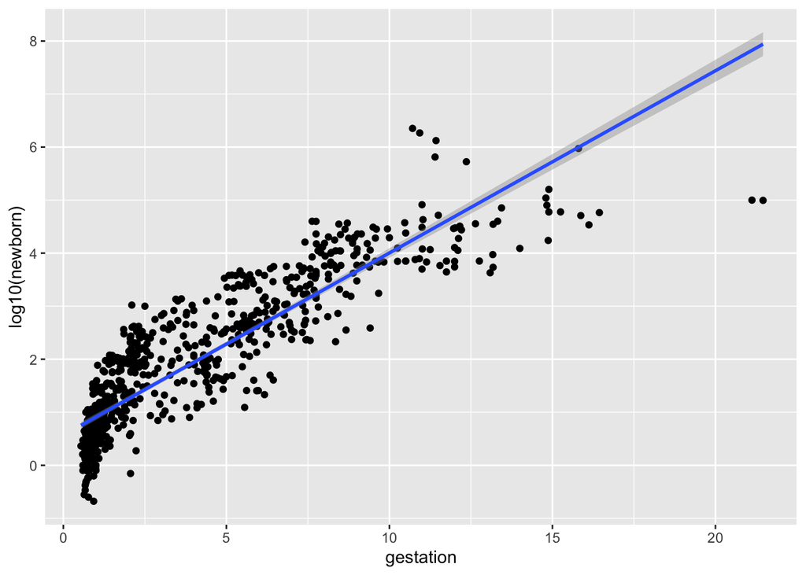

```r
mammals %>%
  ggplot(mapping=aes(x=gestation,y=log10(newborn)))+ #log it bc the graph looks weird
  geom_point()+
  geom_smooth(method="lm")
```

4. Which mammal has the longest life span in years?

```r
mammals %>%
  select(genus,species,max_life) %>%
  mutate(max_life_new=max_life/12) %>%
  arrange(desc(max_life_new))
```

```
## # A tibble: 1,440 × 4
##    genus        species      max_life max_life_new
##    <chr>        <chr>           <dbl>        <dbl>
##  1 Balaenoptera physalus         1368          114
##  2 Balaenoptera musculus         1320          110
##  3 Balaena      mysticetus       1200          100
##  4 Orcinus      orca             1080           90
##  5 Berardius    bairdii          1008           84
##  6 Elephas      maximus           960           80
##  7 Megaptera    novaeangliae      924           77
##  8 Physeter     catodon           924           77
##  9 Balaenoptera borealis          888           74
## 10 Dugong       dugon             876           73
## # ℹ 1,430 more rows
```

5. Do larger mammals live longer?

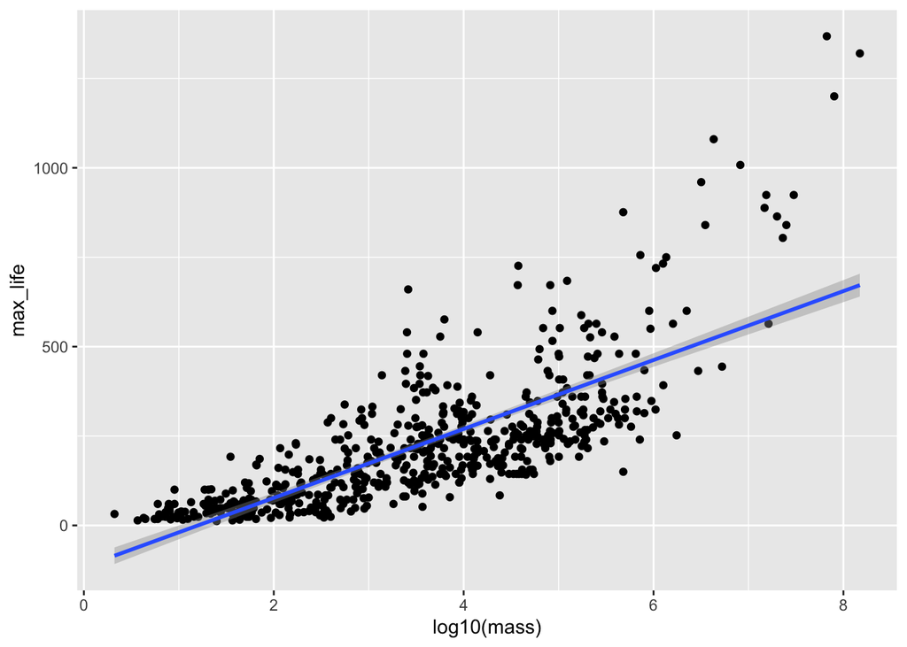

```r
mammals %>%
  ggplot(mapping=aes(x=log10(mass),y=max_life))+
  geom_point()+
  geom_smooth(method="lm")
```

–>[Home](https://jmledford3115.github.io/datascibiol/)